# Introduction to Data Visualization with Python

- Wiliam Surles
- 2017-11-10
- Datacamp class
- https://www.datacamp.com/courses/introduction-to-data-visualization-with-python

## Whats Covered

- Customizing plots
  - Plotting multiple graphs
  - Customizing axes
  - Legends, annotations, and styles
- Plotting 2D arrays
  - Working with 2D arrays
  - Visualizing bivariate functions
  - Visualizing bivariate distributions
  - Working with images
- Statistical plots with Seaborn
  - Visualizing regressions
  - Visualizing univariate distributions
  - Visualizing multivariate distributions
- Analyzing time series and images
  - Visualizing time series
  - Time series with moving windows
  - Histogram equalization in images
  - Congratulations!!

## Additional Resources

## Libraries and Data

```python
import numpy as np
import pandas as pd
import matplotlib.pyplot as plt
```

# Customizing plots

## Plotting multiple graphs

#### Strategies

- Plotting many graphs on common axes
- Creating axes within a figure
- Creating subplots within a figure

#### The axes() command

- Syntax: `axes([x_lo, y_lo, width, height])`
- Units between 0 and 1 (figure dimensions)

#### The subplot() command

- Syntax: `subplot(nrows, ncols, nsubplot)`
- Subplot ordering:
  - Row-wise from top left
  - Indexed from 1

### Multiple plots on single axis

#### First, lets make some data to use in the next exercises

```python
year = np.asarray([1970, 1971, 1972, 1973, 1974, 1975, 1976, 1977, 1978, 1979, 1980,
       1981, 1982, 1983, 1984, 1985, 1986, 1987, 1988, 1989, 1990, 1991,
       1992, 1993, 1994, 1995, 1996, 1997, 1998, 1999, 2000, 2001, 2002,
       2003, 2004, 2005, 2006, 2007, 2008, 2009, 2010, 2011])

physical_sciences = np.asarray([ 13.8,  14.9,  14.8,  16.5,  18.2,  19.1,  20. ,  21.3,  22.5,
        23.7,  24.6,  25.7,  27.3,  27.6,  28. ,  27.5,  28.4,  30.4,
        29.7,  31.3,  31.6,  32.6,  32.6,  33.6,  34.8,  35.9,  37.3,
        38.3,  39.7,  40.2,  41. ,  42.2,  41.1,  41.7,  42.1,  41.6,
        40.8,  40.7,  40.7,  40.7,  40.2,  40.1])

computer_science = np.asarray([ 13.6,  13.6,  14.9,  16.4,  18.9,  19.8,  23.9,  25.7,  28.1,
        30.2,  32.5,  34.8,  36.3,  37.1,  36.8,  35.7,  34.7,  32.4,
        30.8,  29.9,  29.4,  28.7,  28.2,  28.5,  28.5,  27.5,  27.1,
        26.8,  27. ,  28.1,  27.7,  27.6,  27. ,  25.1,  22.2,  20.6,
        18.6,  17.6,  17.8,  18.1,  17.6,  18.2])

health = np.asarray([ 77.1,  75.5,  76.9,  77.4,  77.9,  78.9,  79.2,  80.5,  81.9,
        82.3,  83.5,  84.1,  84.4,  84.6,  85.1,  85.3,  85.7,  85.5,
        85.2,  84.6,  83.9,  83.5,  83. ,  82.4,  81.8,  81.5,  81.3,
        81.9,  82.1,  83.5,  83.5,  85.1,  85.8,  86.5,  86.5,  86. ,
        85.9,  85.4,  85.2,  85.1,  85. ,  84.8])

education = np.asarray([ 74.53532758,  74.14920369,  73.55451996,  73.50181443,
        73.33681143,  72.80185448,  72.16652471,  72.45639481,
        73.19282134,  73.82114234,  74.98103152,  75.84512345,
        75.84364914,  75.95060123,  75.86911601,  75.92343971,
        76.14301516,  76.96309168,  77.62766177,  78.11191872,
        78.86685859,  78.99124597,  78.43518191,  77.26731199,
        75.81493264,  75.12525621,  75.03519921,  75.1637013 ,
        75.48616027,  75.83816206,  76.69214284,  77.37522931,
        78.64424394,  78.54494815,  78.65074774,  79.06712173,
        78.68630551,  78.72141311,  79.19632674,  79.5329087 ,
        79.61862451,  79.43281184])
```

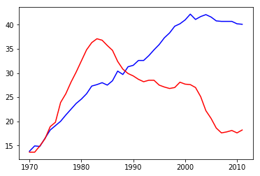

```python
# Import matplotlib.pyplot
import matplotlib.pyplot as plt

# Plot in blue the % of degrees awarded to women in the Physical Sciences
plt.plot(year, physical_sciences, color='blue')

# Plot in red the % of degrees awarded to women in Computer Science
plt.plot(year, computer_science, color='red')

# Display the plot
plt.show()
```

### Using axes()

- Rather than overlaying line plots on common axes, you may prefer to plot different line plots on distinct axes.
- The command `plt.axes()` is one way to do this (but it requires specifying coordinates relative to the size of the figure).
- `plt.axes([xlo, ylo, width, height])`
- Note that these coordinates can be passed to `plt.axes()` in the form of a list or a tuple.

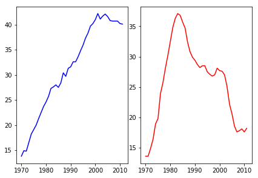

```python
# Create plot axes for the first line plot
plt.axes([0.05, 0.05, 0.425, 0.9])

# Plot in blue the % of degrees awarded to women in the Physical Sciences
plt.plot(year, physical_sciences, color='blue')

# Create plot axes for the second line plot
plt.axes([0.525, 0.05, 0.425, 0.9])

# Plot in red the % of degrees awarded to women in Computer Science
plt.plot(year, computer_science, color='red')

# Display the plot
plt.show()
```

### Using subplot() (1)

- The command `plt.axes()` requires a lot of effort to use well because the coordinates of the axes need to be set manually.
- A better alternative is to use `plt.subplot()` to determine the layout automatically.

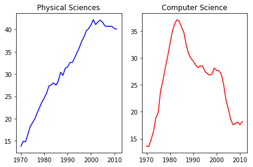

```python
# Create a figure with 1x2 subplot and make the left subplot active
plt.subplot(1,2,1)

# Plot in blue the % of degrees awarded to women in the Physical Sciences
plt.plot(year, physical_sciences, color='blue')
plt.title('Physical Sciences')

# Make the right subplot active in the current 1x2 subplot grid
plt.subplot(1,2,2)

# Plot in red the % of degrees awarded to women in Computer Science
plt.plot(year, computer_science, color='red')
plt.title('Computer Science')

# Use plt.tight_layout() to improve the spacing between subplots
plt.tight_layout()
plt.show()
```

### Using subplot() (2)

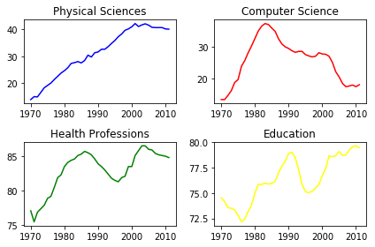

```python
# Create a figure with 2x2 subplot layout and make the top left subplot active
plt.subplot(2,2,1)

# Plot in blue the % of degrees awarded to women in the Physical Sciences
plt.plot(year, physical_sciences, color='blue')
plt.title('Physical Sciences')

# Make the top right subplot active in the current 2x2 subplot grid
plt.subplot(2,2,2)

# Plot in red the % of degrees awarded to women in Computer Science
plt.plot(year, computer_science, color='red')
plt.title('Computer Science')

# Make the bottom left subplot active in the current 2x2 subplot grid
plt.subplot(2,2,3)

# Plot in green the % of degrees awarded to women in Health Professions
plt.plot(year, health, color='green')
plt.title('Health Professions')

# Make the bottom right subplot active in the current 2x2 subplot grid
plt.subplot(2,2,4)

# Plot in yellow the % of degrees awarded to women in Education
plt.plot(year, education, color='yellow')
plt.title('Education')

# Improve the spacing between subplots and display them
plt.tight_layout()
plt.show()
```

## Customizing axes

#### Controlling axis extents

- `axis([xmin, xmax, ymin, ymax])` sets axis extents
- Control over individual axis extents
  - `xlim([xmin, xmax])`
  - `ylim([ymin, ymax])`
- Can use tuples, lists for extents
  - e.g. `xlim((-2,3))` works
  - e.g. `xlim([-2,3])` works also

#### Other axis options

- `axis('off')`
  - turns off axis lines, labels
- `axis('equal')`
  - equal scalling on x, y axes
- `axis('square')`
  - forces square plot
- `axis('tight')`
  - sets xlim(), ylim(), to show all data

### Using xlim(), ylim()

- Here we also save the figure to a png file
- You have to save the figure before you call `plt.show()` or it will reset to a new plot and you will just get a blank image

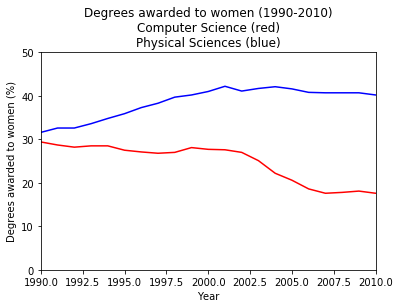

```python
# Plot the % of degrees awarded to women in Computer Science and the Physical Sciences
plt.plot(year,computer_science, color='red')
plt.plot(year, physical_sciences, color='blue')

# Add the axis labels
plt.xlabel('Year')
plt.ylabel('Degrees awarded to women (%)')

# Set the x-axis range
plt.xlim(1990, 2010)

# Set the y-axis range
plt.ylim(0, 50)

# Add a title and display the plot
plt.title('Degrees awarded to women (1990-2010)\nComputer Science (red)\nPhysical Sciences (blue)')

# Save the image as 'xlim_and_ylim.png'
plt.savefig('plots/xlim_and_ylim.png')

plt.show()
```

### Using axis()

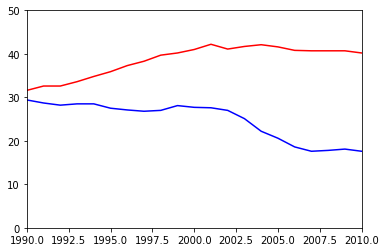

```python
# Plot in blue the % of degrees awarded to women in Computer Science
plt.plot(year,computer_science, color='blue')

# Plot in red the % of degrees awarded to women in the Physical Sciences
plt.plot(year, physical_sciences,color='red')

# Set the x-axis and y-axis limits
plt.axis((1990, 2010, 0, 50))

# Save the figure as 'axis_limits.png'
plt.savefig('plots/axis_limits.png')

# Show the figure
plt.show()
```

## Legends, annotations, and styles

#### Legends

- provide labels for overlaid points and curves
- you can set the locations with strings or numerical codes
  - strings are easier to remember. things like 'upper left' or 'center'
- `plt.legend(loc = 'upper right')`

#### Plot annotations

- Text labels and arrows using `annotate()` method
- Flexible specification of coordinates
- Keyword arrowprops: dict of arrow properties
  - width
  - color
  - etc.
- `plt.annotate('setosa', xy=(5.0, 3.5))`
- options for annotate
  - s - text of label
  - xy - coordinates to annotate
  - xytext - coordinates of label
  - arrowprops - controls drawing of arrow
- `plt.annotate('setosa', xy = (5.0, 3.5), xytext = (4.25, 4.0), arrowprops = {'color':'red'})`

#### Working with plot styles

- Style sheets in Matplotlib
- Defaults for lines, points, backgrounds, etc.
- Switch style globally with `plt.style.use()`
- `plt.style.available`: list of styles
  - `plt.style.use('ggplot')`
  - `plt.style.use('fivethirtyeight')`

### Using legend()

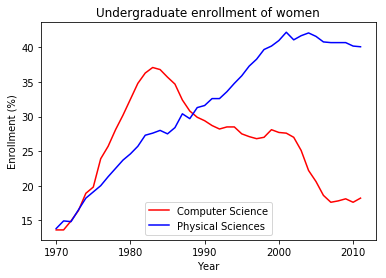

```python
# Specify the label 'Computer Science'
plt.plot(year, computer_science, color='red', label='Computer Science')

# Specify the label 'Physical Sciences'
plt.plot(year, physical_sciences, color='blue', label='Physical Sciences')

# Add a legend at the lower center
plt.legend(loc = 'lower center')

# Add axis labels and title
plt.xlabel('Year')
plt.ylabel('Enrollment (%)')
plt.title('Undergraduate enrollment of women')
plt.show()
```

### Using annotate()

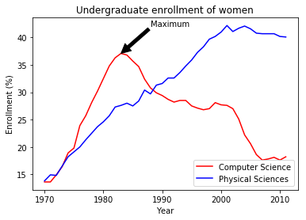

```python
# Plot with legend as before
plt.plot(year, computer_science, color='red', label='Computer Science')
plt.plot(year, physical_sciences, color='blue', label='Physical Sciences')
plt.legend(loc='lower right')

# Compute the maximum enrollment of women in Computer Science: cs_max
cs_max = np.asarray(computer_science).max()

# Calculate the year in which there was maximum enrollment of women in Computer Science: yr_max
yr_max = year[np.asarray(computer_science).argmax()]

# Add a black arrow annotation
plt.annotate('Maximum',
    xy = (yr_max, cs_max),
    xytext = (yr_max + 5, cs_max + 5),
    arrowprops = dict(facecolor = 'black')
    )

# Add axis labels and title
plt.xlabel('Year')
plt.ylabel('Enrollment (%)')
plt.title('Undergraduate enrollment of women')
plt.show()
```

### Modifying styles

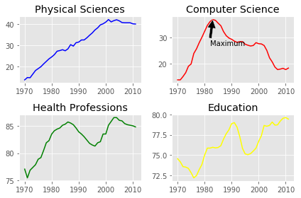

```python
# Set the style to 'ggplot'
plt.style.use('ggplot')

# Create a figure with 2x2 subplot layout
plt.subplot(2, 2, 1)

# Plot the enrollment % of women in the Physical Sciences
plt.plot(year, physical_sciences, color='blue')
plt.title('Physical Sciences')

# Plot the enrollment % of women in Computer Science
plt.subplot(2, 2, 2)
plt.plot(year, computer_science, color='red')
plt.title('Computer Science')

# Add annotation
cs_max = computer_science.max()
yr_max = year[computer_science.argmax()]
plt.annotate('Maximum', xy=(yr_max, cs_max), xytext=(yr_max-1, cs_max-10), arrowprops=dict(facecolor='black'))

# Plot the enrollmment % of women in Health professions
plt.subplot(2, 2, 3)
plt.plot(year, health, color='green')
plt.title('Health Professions')

# Plot the enrollment % of women in Education
plt.subplot(2, 2, 4)
plt.plot(year, education, color='yellow')
plt.title('Education')

# Improve spacing between subplots and display them
plt.tight_layout()
plt.show()
```

Now put the plot style back to normal

```python
plt.style.use('default')
```

# Plotting 2D arrays

## Working with 2D arrays

#### Reminder: NumPy arrays

- Homogeneouse in type
- Calculations all at once
- Indexing with brackets:
  - A[index] for 1D array
  - A[index_0, index_1] for 2D array

#### Reminder: Slicing arrays

- Slicing:
  - 1D arrays: A[slice],
  - 2D arrays: A[slice_0, slice_1]
- Slicing: slice = start:stop:stride
  - Indexes from start to stop-1 in steps of stride
  - Missing start: implicitly at beginning of array
  - Missing stop: implicitly at end of array
  - Missing stride: implicitly stride 1
- Negative indexes/slices: count from end of array

#### Using meshgrid()

```python
u = np.linspace(-2,2,3)
v = np.linspace(-1,1,5)
X,Y = np.meshgrid(u,v)
Z = X**2/25 + Y**2/4
```

#### Orientations of 2D arrays and images

- arrays increase from left to right and top to bottom (like we read)
- pcolor increases form left to right and bottom to top (like scales on an axis)

### Generating meshes

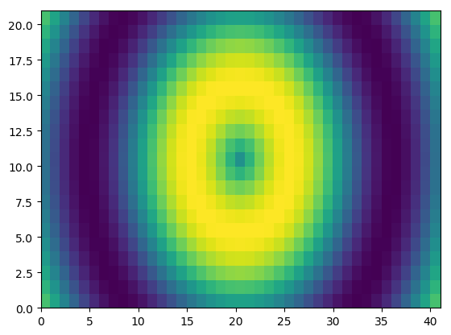

```python
# Import numpy and matplotlib.pyplot
import numpy as np
import matplotlib.pyplot as plt

# Generate two 1-D arrays: u, v
u = np.linspace(-2, 2, 41)
v = np.linspace(-1, 1, 21)

# Generate 2-D arrays from u and v: X, Y
X,Y = np.meshgrid(u,v)

# Compute Z based on X and Y
Z = np.sin(3*np.sqrt(X**2 + Y**2))

# Display the resulting image with pcolor()
plt.pcolor(Z)

# Save the figure to 'sine_mesh.png'
plt.savefig('plots/sine_mesh.png')

plt.show()
```

### Array orientation

- remember that the array is ploted from [left to right] and [bottom to top]
  - so this array, A, will have the same color on top

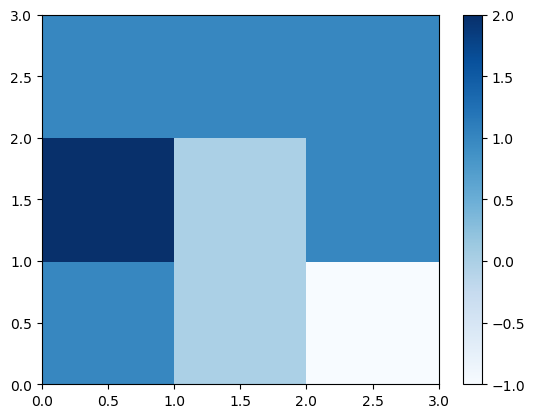

```python
A = np.array([[1, 0, -1], [2, 0, 1], [1, 1, 1]])
plt.pcolor(A, cmap='Blues')
plt.colorbar()
plt.show()
```

## Visualizing bivariate functions

#### Fixing a color map

- Just plotting the grid will have a few problems:
  - axes based on the indicies
  - white space on the top and bottom,
  - no scale for the color
- to fix this:
  - pass X and Y as the first two arguments to `pcolor()`
  - use `plt.axis('tight')` to remove extra whitespace
  - use `plt.colorbar()` to add the scale color legend

#### Color map

- there are many color options that can be passed to `cmap` argument in `pcolor()`
  - 'gray', 'autum', etc,

#### Contour plots

- `plt.contour(Z)`
- add more countour lines
  - `plt.countour(Z, 30)`
- fill the colors with `contourf()`
  - `plt.contourf(X,Y,Z,30)`

### Contour & filled contour plots

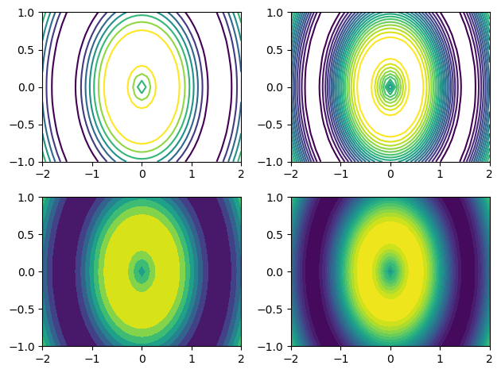

```python
# Generate a default contour map of the array Z
plt.subplot(2,2,1)
plt.contour(X, Y, Z)

# Generate a contour map with 20 contours
plt.subplot(2,2,2)
plt.contour(X, Y, Z, 20)

# Generate a default filled contour map of the array Z
plt.subplot(2,2,3)
plt.contourf(X, Y, Z)

# Generate a default filled contour map with 20 contours
plt.subplot(2,2,4)
plt.contourf(X, Y, Z, 20)

# Improve the spacing between subplots
plt.tight_layout()

# Display the figure
plt.show()
```

### Modifying colormaps

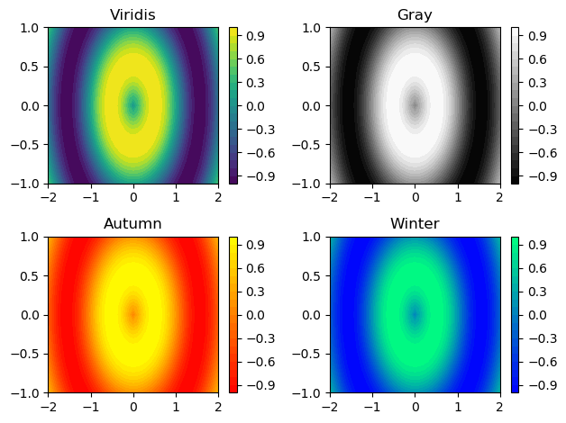

```python
# Create a filled contour plot with a color map of 'viridis'
plt.subplot(2,2,1)
plt.contourf(X,Y,Z,20, cmap='viridis')
plt.colorbar()
plt.title('Viridis')

# Create a filled contour plot with a color map of 'gray'
plt.subplot(2,2,2)
plt.contourf(X,Y,Z,20, cmap='gray')
plt.colorbar()
plt.title('Gray')

# Create a filled contour plot with a color map of 'autumn'
plt.subplot(2,2,3)
plt.contourf(X,Y,Z,20, cmap='autumn')
plt.colorbar()
plt.title('Autumn')

# Create a filled contour plot with a color map of 'winter'
plt.subplot(2,2,4)
plt.contourf(X,Y,Z,20, cmap='winter')
plt.colorbar()
plt.title('Winter')

# Improve the spacing between subplots and display them
plt.tight_layout()
plt.show()
```

## Visualizing bivariate distributions

#### Distributions of 2D points

- 2D points given as two 1D arrays x and y
- Goal: generate a 2D histogram from x and y

#### Histograms in 1D

- Choose bins(intervals)
- Count realizations withing bins and plot
- `counts, bins, patches = plt.hist(x, bins=25)`

#### Bins in 2D

- Different shapes available for binning points
- Common choices: rectangles and hexagons
- Rectangular binning
  - plt.hist2d(x,y, bins = (10, 20))
- Hexagonal binning
  - plt.hexbin(x,y, gridsize = (15, 10))

### Using hist2d()

- Given a set of ordered pairs describing data points, you can count the number of points with similar values to construct a two-dimensional histogram.
- This is similar to a one-dimensional histogram, but it describes the joint variation of two random variables rather than just one.
- In matplotlib, one function to visualize 2-D histograms is `plt.hist2d()`
  - You specify the coordinates of the points using `plt.hist2d(x,y)` assuming `x` and `y` are two vectors of the same length.
  - You can specify the number of bins with the argument `bins=(nx, ny)` where `nx` is the number of bins to use in the horizontal direction and `ny` is the number of bins to use in the vertical direction.
  - You can specify the rectangular region in which the samples are counted in constructing the 2D histogram. The optional parameter required is `range=((xmin, xmax), (ymin, ymax))` where
  - `xmin` and `xmax` are the respective lower and upper limits for the variables on the x-axis and
  - `ymin` and `ymax` are the respective lower and upper limits for the variables on the y-axis. Notice that the optional `range` argument can use nested tuples or lists.

```python
file = 'https://assets.datacamp.com/production/course_1761/datasets/auto-mpg.csv'
auto = pd.read_csv(file)
auto.head()
```

|  | mpg | cyl | displ | hp | weight | accel | yr | origin | name | color | size | marker |
| --- | --- | --- | --- | --- | --- | --- | --- | --- | --- | --- | --- | --- |
| 0 | 18.0 | 6 | 250.0 | 88 | 3139 | 14.5 | 71 | US | ford mustang | red | 27.370336 | o |
| 1 | 9.0 | 8 | 304.0 | 193 | 4732 | 18.5 | 70 | US | hi 1200d | green | 62.199511 | o |
| 2 | 36.1 | 4 | 91.0 | 60 | 1800 | 16.4 | 78 | Asia | honda civic cvcc | blue | 9.000000 | x |
| 3 | 18.5 | 6 | 250.0 | 98 | 3525 | 19.0 | 77 | US | ford granada | red | 34.515625 | o |
| 4 | 34.3 | 4 | 97.0 | 78 | 2188 | 15.8 | 80 | Europe | audi 4000 | blue | 13.298178 | s |

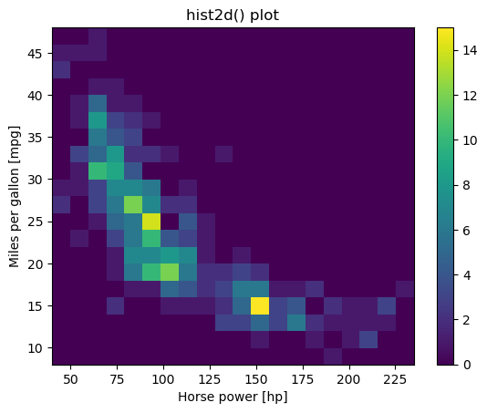

```python
# Generate a 2-D histogram
plt.hist2d(auto.hp, auto.mpg, bins = (20,20), range = ((40, 235),(8,48)))

# Add a color bar to the histogram
plt.colorbar()

# Add labels, title, and display the plot
plt.xlabel('Horse power [hp]')
plt.ylabel('Miles per gallon [mpg]')
plt.title('hist2d() plot')
plt.show()
```

### Using hexbin()

- As an alternative, the function plt.hexbin() uses hexagonal bins.
- The underlying algorithm (based on [this article from 1987](http://amstat.tandfonline.com/doi/abs/10.1080/01621459.1987.10478445)) constructs a hexagonal tesselation of a planar region and aggregates points inside hexagonal bins.
  - The optional `gridsize` argument (default 100) gives the number of hexagons across the x-direction used in the hexagonal tiling. If specified as a list or a tuple of length two, `gridsize` fixes the number of hexagon in the x- and y-directions respectively in the tiling.
  - The optional parameter `extent=(xmin, xmax, ymin, ymax)` specifies rectangular region covered by the hexagonal tiling. In that case, `xmin` and `xmax` are the respective lower and upper limits for the variables on the x-axis and `ymin` and `ymax` are the respective lower and upper limits for the variables on the y-axis.

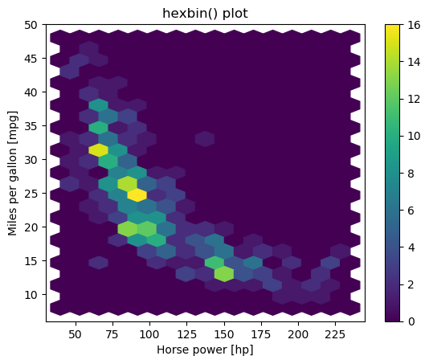

```python
# Generate a 2d histogram with hexagonal bins
plt.hexbin(auto.hp, auto.mpg, gridsize = (15, 12), extent = (40, 235, 8, 48))


# Add a color bar to the histogram
plt.colorbar()

# Add labels, title, and display the plot
plt.xlabel('Horse power [hp]')
plt.ylabel('Miles per gallon [mpg]')
plt.title('hexbin() plot')
plt.show()
```

## Working with images

#### Images

- Grayscale images: rectangular 2D arrays
- Color images: typically three 2D arrays (channels)
  - RGB(Red-Green-Blue)
- Channel values:
  - 0 to 1 (floating-point numbers)
  - 0 to 255 (8 bit integers)

#### Loading and displaying images

- `img = plt.imread('sunflower.jpg')`
- `plt.imshow(img)`
  - still need to call `plt.show()`

#### eduction to gray-scale image

- averaging the 3 color matrices is a reasonable proxy
- `collapsed = img.mean(axis=2)`
- `plt.set_cmap('gray')`

#### Uneven samples

- `uneven = collapsed[::4, ::2]`
- `plt.imshow(uneven)`

#### Adjusting aspect ratio

- `plt.imshow(uneven, aspect=2.0)`

#### Adjusting extent

- `plt.imshow(uneven, cmap='gray', extent = (0, 640, 0, 480))`

### Loading, examining images

```
(225, 225, 3)
```

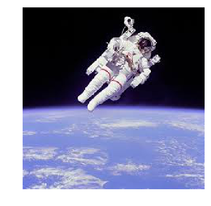

```python
# Load the image into an array: img
img = plt.imread('images/480px-Astronaut-EVA.jpg')

# Print the shape of the image
print(img.shape)

# Display the image
plt.imshow(img)

# Hide the axes
plt.axis('off')
plt.show()
```

### Pseudocolor plot from image data

```
(225, 225, 3)
(225, 225)
```

[figure not shown]

```python
# Load the image into an array: img
img = plt.imread('images/480px-Astronaut-EVA.jpg')

# Print the shape of the image
print(img.shape)

# Compute the sum of the red, green and blue channels: intensity
intensity = img.sum(axis=2)

# Print the shape of the intensity
print(intensity.shape)

# Display the intensity with a colormap of 'gray'
plt.imshow(intensity, cmap='gray')

# Add a colorbar
plt.colorbar()

# Hide the axes and show the figure
plt.axis('off')
plt.show()
```

### Extent and aspect

- When using `plt.imshow()` to display an array, the default behavior is to keep pixels square so that the height to width ratio of the output matches the ratio determined by the shape of the array.
  - In addition, by default, the x- and y-axes are labeled by the number of samples in each direction.
- The ratio of the displayed width to height is known as the image aspect
- The range used to label the x- and y-axes is known as the image extent.
- The default aspect value of 'auto' keeps the pixels square and the extents are automatically computed from the shape of the array if not specified otherwise.

[figure not shown]

```python
# Load the image into an array: img
img = plt.imread('images/480px-Astronaut-EVA.jpg')

# Specify the extent and aspect ratio of the top left subplot
plt.subplot(2,2,1)
plt.title('extent=(-1,1,-1,1),\naspect=0.5')
plt.xticks([-1,0,1])
plt.yticks([-1,0,1])
plt.imshow(img, extent=(-1,1,-1,1), aspect=0.5)

# Specify the extent and aspect ratio of the top right subplot
plt.subplot(2,2,2)
plt.title('extent=(-1,1,-1,1),\naspect=1')
plt.xticks([-1,0,1])
plt.yticks([-1,0,1])
plt.imshow(img, extent=(-1,1,-1,1), aspect=1)

# Specify the extent and aspect ratio of the bottom left subplot
plt.subplot(2,2,3)
plt.title('extent=(-1,1,-1,1),\naspect=2')
plt.xticks([-1,0,1])
plt.yticks([-1,0,1])
plt.imshow(img, extent=(-1,1,-1,1), aspect=2)

# Specify the extent and aspect ratio of the bottom right subplot
plt.subplot(2,2,4)
plt.title('extent=(-2,2,-1,1),\naspect=2')
plt.xticks([-2,-1,0,1,2])
plt.yticks([-1,0,1])
plt.imshow(img, extent=(-2,2,-1,1), aspect=2)

# Improve spacing and display the figure
plt.tight_layout()
plt.show()
```

### Rescaling pixel intensities

```python
# Load the image into an array: image
image = plt.imread('images/640px-Unequalized_Hawkes_Bay_NZ.jpg')

# print(image.shape)
```

[output not shown]

```python
# Extract minimum and maximum values from the image: pmin, pmax
pmin, pmax = image.min(), image.max()
print("The smallest & largest pixel intensities are %d & %d." % (pmin, pmax))
```

```
The smallest & largest pixel intensities are 104 & 230.
```

```python
# Rescale the pixels: rescaled_image
rescaled_image = (256*(image - pmin) / (pmax - pmin)).astype(int)
print("The rescaled smallest & largest pixel intensities are %.1f & %.1f." %
      (rescaled_image.min(), rescaled_image.max()))
```

```
The rescaled smallest & largest pixel intensities are 0.0 & 256.0.
```

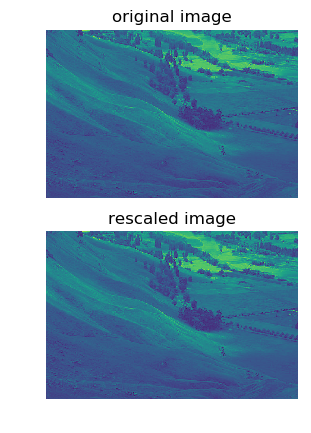

```python
# Display the original image in the top subplot
plt.subplot(2,1,1)
plt.title('original image')
plt.axis('off')
plt.imshow(image)

# Display the rescaled image in the bottom subplot
plt.subplot(2,1,2)
plt.title('rescaled image')
plt.axis('off')
plt.imshow(rescaled_image)

plt.show()
```

For whatever reason this is not changing. hmmmm

# Statistical plots with Seaborn

## Visualizing regressions

### Simple linear regressions

### Plotting residuals of a regression

### Higher-order regressions

### Grouping linear regressions by hue

### Grouping linear regressions by row or column

## Visualizing univariate distributions

### Constructing strip plots

### Constructing swarm plots

### Constructing violin plots

## Visualizing multivariate distributions

### Plotting joint distributions (1)

### Plotting joint distributions (2)

### Plotting distributions pairwise (1)

### Plotting distributions pairwise (2)

### Visualizing correlations with a heatmap

# Analyzing time series and images

## Visualizing time series

### Multiple time series on common axes

### Multiple time series slices (1)

### Multiple time series slices (2)

### Plotting an inset view

## Time series with moving windows

### Plotting moving averages

### Plotting moving standard deviations

### Interpreting moving statistics

## Histogram equalization in images

### Extracting a histogram from a grayscale image

### Cumulative Distribution Function from an image histogram

### Equalizing an image histogram

### Extracting histograms from a color image

### Extracting bivariate histograms from a color image

## Congratulations!!